```r
# cargamos datos
datos <- read.csv("Data.csv")

##ver el dataframe
datos
```

```
##          Country                         League                          Club
## 1          Spain                        La Liga                         (BET)
## 2          Spain                        La Liga                         (BAR)
## 3          Spain                        La Liga                         (ATL)
## 4          Spain                        La Liga                         (CAR)
## 5          Spain                        La Liga                         (VAL)
## 6          Spain                        La Liga                         (JUV)
## 7          Spain                        La Liga                         (RMA)
## 8          Spain                        La Liga                         (PSG)
## 9          Spain                        La Liga                         (CEL)
## 10         Spain                        La Liga                         (EIB)
## 11         Spain                        La Liga                          None
## 12         Spain                        La Liga                         (HUE)
## 13         Spain                        La Liga                         (BAR)
## 14         Spain                        La Liga                         (VIL)
```

[output cut: 2629 more lines]

## CARGAMOS LIBRERIAS

```r
library(knitr)
library(dplyr)
```

## VEMOS TODAS LAS COLUMNAS ALINEADAS

```r
kable(datos)
```

| Country | League | Club | Player.Names | Matches_Played | Substitution | Mins | Goals | xG | xG.Per.Avg.Match | Shots | OnTarget | Shots.Per.Avg.Match | On.Target.Per.Avg.Match | Year |
| --- | --- | --- | --- | --- | --- | --- | --- | --- | --- | --- | --- | --- | --- | --- |
| Spain | La Liga | (BET) | Juanmi Callejon | 19 | 16 | 1849 | 11 | 6.62 | 0.34 | 48 | 20 | 2.47 | 1.03 | 2016 |
| Spain | La Liga | (BAR) | Antoine Griezmann | 36 | 0 | 3129 | 16 | 11.86 | 0.36 | 88 | 41 | 2.67 | 1.24 | 2016 |
| Spain | La Liga | (ATL) | Luis Suarez | 34 | 1 | 2940 | 28 | 23.21 | 0.75 | 120 | 57 | 3.88 | 1.84 | 2016 |
| Spain | La Liga | (CAR) | Ruben Castro | 32 | 3 | 2842 | 13 | 14.06 | 0.47 | 117 | 42 | 3.91 | 1.40 | 2016 |
| Spain | La Liga | (VAL) | Kevin Gameiro | 21 | 10 | 1745 | 13 | 10.65 | 0.58 | 50 | 23 | 2.72 | 1.25 | 2016 |
| Spain | La Liga | (JUV) | Cristiano Ronaldo | 29 | 0 | 2634 | 25 | 24.68 | 0.89 | 162 | 60 | 5.84 | 2.16 | 2016 |
| Spain | La Liga | (RMA) | Karim Benzema | 23 | 6 | 1967 | 11 | 13.25 | 0.64 | 69 | 34 | 3.33 | 1.64 | 2016 |
| Spain | La Liga | (PSG) | Neymar | 30 | 0 | 2694 | 13 | 13.33 | 0.47 | 105 | 42 | 3.70 | 1.48 | 2016 |
| Spain | La Liga | (CEL) | Iago Aspas | 25 | 7 | 2354 | 19 | 13.88 | 0.56 | 78 | 37 | 3.15 | 1.49 | 2016 |
| Spain | La Liga | (EIB) | Sergi Enrich | 31 | 7 | 2904 | 11 | 8.25 | 0.27 | 64 | 26 | 2.09 | 0.85 | 2016 |
| Spain | La Liga | None | Aduriz | 27 | 5 | 2480 | 16 | 15.92 | 0.61 | 85 | 45 | 3.26 | 1.72 | 2016 |
| Spain | La Liga | (HUE) | Sandro Ramlrez | 28 | 2 | 2340 | 14 | 7.14 | 0.29 | 93 | 38 | 3.78 | 1.54 | 2016 |
| Spain | La Liga | (BAR) | Lionel Messi | 32 | 2 | 2910 | 37 | 26.65 | 0.87 | 179 | 76 | 5.84 | 2.48 | 2016 |
| Spain | La Liga | (VIL) | Gerard Moreno | 37 | 0 | 3361 | 13 | 8.49 | 0.24 | 82 | 32 | 2.32 | 0.90 | 2016 |
| Spain | La Liga | (JUV) | Morata | 14 | 12 | 1392 | 15 | 9.67 | 0.66 | 55 | 30 | 3.75 | 2.05 | 2016 |
| Spain | La Liga | (MON) | Wissam Ben Yedder | 20 | 11 | 1735 | 11 | 7.85 | 0.43 | 44 | 23 | 2.41 | 1.26 | 2016 |
| Spain | La Liga | (SOC) | Willian Jose | 27 | 1 | 2102 | 12 | 8.41 | 0.38 | 69 | 29 | 3.12 | 1.31 | 2016 |
| Spain | La Liga | Florin | Andone | 32 | 5 | 2984 | 12 | 11.62 | 0.37 | 99 | 42 | 3.15 | 1.34 | 2016 |
| Spain | La Liga | (SOC) | Cedric Bakambu | 17 | 9 | 1633 | 10 | 8.08 | 0.47 | 50 | 26 | 2.91 | 1.51 | 2016 |
| Spain | La Liga | (RMA) | Isco | 18 | 12 | 1690 | 10 | 3.91 | 0.22 | 32 | 15 | 1.80 | 0.84 | 2016 |
| Italy | Serie A | (LIV) | Mohamed Salah | 29 | 2 | 2567 | 15 | 11.62 | 0.43 | 80 | 50 | 2.96 | 1.85 | 2016 |
| Italy | Serie A | (SAS) | Gregoire Defrel | 23 | 6 | 2054 | 12 | 8.00 | 0.37 | 43 | 28 | 1.99 | 1.30 | 2016 |
| Italy | Serie A | (LAZ) | Ciro Immobile | 35 | 1 | 3294 | 22 | 19.76 | 0.57 | 136 | 98 | 3.92 | 2.83 | 2016 |
| Italy | Serie A | (VER) | Nikola Kalinic | 26 | 6 | 2648 | 15 | 15.05 | 0.54 | 90 | 61 | 3.23 | 2.19 | 2016 |
| Italy | Serie A | (NAP) | Dries Mertens | 28 | 7 | 2671 | 28 | 21.65 | 0.77 | 148 | 102 | 5.26 | 3.63 | 2016 |
| Italy | Serie A | (ATA) | Alejandro Gomez | 37 | 0 | 3247 | 16 | 11.62 | 0.34 | 117 | 75 | 3.42 | 2.19 | 2016 |
| Italy | Serie A | (FIO) | Jose CallejOn | 37 | 0 | 3276 | 14 | 11.38 | 0.33 | 86 | 57 | 2.49 | 1.65 | 2016 |
| Italy | Serie A | (BEN) | Iago Falque | 31 | 4 | 2633 | 12 | 8.04 | 0.29 | 65 | 42 | 2.35 | 1.52 | 2016 |
| Italy | Serie A | (CAG) | Giovanni Simeone | 29 | 6 | 2764 | 12 | 12.22 | 0.42 | 76 | 35 | 2.61 | 1.20 | 2016 |
| Italy | Serie A | (PSG) | Mauro Icardi | 34 | 0 | 3188 | 24 | 19.13 | 0.57 | 109 | 52 | 3.25 | 1.55 | 2016 |

[output cut: 630 more lines]

##eliminar filas con valores desconocidos

```r
datos <- datos[complete.cases(datos),]
```

## ver columnas y alinearlas

```r
kable(datos)
```

| Country | League | Club | Player.Names | Matches_Played | Substitution | Mins | Goals | xG | xG.Per.Avg.Match | Shots | OnTarget | Shots.Per.Avg.Match | On.Target.Per.Avg.Match | Year |
| --- | --- | --- | --- | --- | --- | --- | --- | --- | --- | --- | --- | --- | --- | --- |
| Spain | La Liga | (BET) | Juanmi Callejon | 19 | 16 | 1849 | 11 | 6.62 | 0.34 | 48 | 20 | 2.47 | 1.03 | 2016 |
| Spain | La Liga | (BAR) | Antoine Griezmann | 36 | 0 | 3129 | 16 | 11.86 | 0.36 | 88 | 41 | 2.67 | 1.24 | 2016 |
| Spain | La Liga | (ATL) | Luis Suarez | 34 | 1 | 2940 | 28 | 23.21 | 0.75 | 120 | 57 | 3.88 | 1.84 | 2016 |
| Spain | La Liga | (CAR) | Ruben Castro | 32 | 3 | 2842 | 13 | 14.06 | 0.47 | 117 | 42 | 3.91 | 1.40 | 2016 |
| Spain | La Liga | (VAL) | Kevin Gameiro | 21 | 10 | 1745 | 13 | 10.65 | 0.58 | 50 | 23 | 2.72 | 1.25 | 2016 |
| Spain | La Liga | (JUV) | Cristiano Ronaldo | 29 | 0 | 2634 | 25 | 24.68 | 0.89 | 162 | 60 | 5.84 | 2.16 | 2016 |
| Spain | La Liga | (RMA) | Karim Benzema | 23 | 6 | 1967 | 11 | 13.25 | 0.64 | 69 | 34 | 3.33 | 1.64 | 2016 |
| Spain | La Liga | (PSG) | Neymar | 30 | 0 | 2694 | 13 | 13.33 | 0.47 | 105 | 42 | 3.70 | 1.48 | 2016 |
| Spain | La Liga | (CEL) | Iago Aspas | 25 | 7 | 2354 | 19 | 13.88 | 0.56 | 78 | 37 | 3.15 | 1.49 | 2016 |
| Spain | La Liga | (EIB) | Sergi Enrich | 31 | 7 | 2904 | 11 | 8.25 | 0.27 | 64 | 26 | 2.09 | 0.85 | 2016 |
| Spain | La Liga | None | Aduriz | 27 | 5 | 2480 | 16 | 15.92 | 0.61 | 85 | 45 | 3.26 | 1.72 | 2016 |
| Spain | La Liga | (HUE) | Sandro Ramlrez | 28 | 2 | 2340 | 14 | 7.14 | 0.29 | 93 | 38 | 3.78 | 1.54 | 2016 |
| Spain | La Liga | (BAR) | Lionel Messi | 32 | 2 | 2910 | 37 | 26.65 | 0.87 | 179 | 76 | 5.84 | 2.48 | 2016 |
| Spain | La Liga | (VIL) | Gerard Moreno | 37 | 0 | 3361 | 13 | 8.49 | 0.24 | 82 | 32 | 2.32 | 0.90 | 2016 |
| Spain | La Liga | (JUV) | Morata | 14 | 12 | 1392 | 15 | 9.67 | 0.66 | 55 | 30 | 3.75 | 2.05 | 2016 |
| Spain | La Liga | (MON) | Wissam Ben Yedder | 20 | 11 | 1735 | 11 | 7.85 | 0.43 | 44 | 23 | 2.41 | 1.26 | 2016 |
| Spain | La Liga | (SOC) | Willian Jose | 27 | 1 | 2102 | 12 | 8.41 | 0.38 | 69 | 29 | 3.12 | 1.31 | 2016 |
| Spain | La Liga | Florin | Andone | 32 | 5 | 2984 | 12 | 11.62 | 0.37 | 99 | 42 | 3.15 | 1.34 | 2016 |
| Spain | La Liga | (SOC) | Cedric Bakambu | 17 | 9 | 1633 | 10 | 8.08 | 0.47 | 50 | 26 | 2.91 | 1.51 | 2016 |
| Spain | La Liga | (RMA) | Isco | 18 | 12 | 1690 | 10 | 3.91 | 0.22 | 32 | 15 | 1.80 | 0.84 | 2016 |
| Italy | Serie A | (LIV) | Mohamed Salah | 29 | 2 | 2567 | 15 | 11.62 | 0.43 | 80 | 50 | 2.96 | 1.85 | 2016 |
| Italy | Serie A | (SAS) | Gregoire Defrel | 23 | 6 | 2054 | 12 | 8.00 | 0.37 | 43 | 28 | 1.99 | 1.30 | 2016 |
| Italy | Serie A | (LAZ) | Ciro Immobile | 35 | 1 | 3294 | 22 | 19.76 | 0.57 | 136 | 98 | 3.92 | 2.83 | 2016 |
| Italy | Serie A | (VER) | Nikola Kalinic | 26 | 6 | 2648 | 15 | 15.05 | 0.54 | 90 | 61 | 3.23 | 2.19 | 2016 |
| Italy | Serie A | (NAP) | Dries Mertens | 28 | 7 | 2671 | 28 | 21.65 | 0.77 | 148 | 102 | 5.26 | 3.63 | 2016 |
| Italy | Serie A | (ATA) | Alejandro Gomez | 37 | 0 | 3247 | 16 | 11.62 | 0.34 | 117 | 75 | 3.42 | 2.19 | 2016 |
| Italy | Serie A | (FIO) | Jose CallejOn | 37 | 0 | 3276 | 14 | 11.38 | 0.33 | 86 | 57 | 2.49 | 1.65 | 2016 |
| Italy | Serie A | (BEN) | Iago Falque | 31 | 4 | 2633 | 12 | 8.04 | 0.29 | 65 | 42 | 2.35 | 1.52 | 2016 |
| Italy | Serie A | (CAG) | Giovanni Simeone | 29 | 6 | 2764 | 12 | 12.22 | 0.42 | 76 | 35 | 2.61 | 1.20 | 2016 |
| Italy | Serie A | (PSG) | Mauro Icardi | 34 | 0 | 3188 | 24 | 19.13 | 0.57 | 109 | 52 | 3.25 | 1.55 | 2016 |

[output cut: 630 more lines]

## ver columnas y alinearlas

```r
names(datos)
```

```
##  [1] "Country"                 "League"
##  [3] "Club"                    "Player.Names"
##  [5] "Matches_Played"          "Substitution"
##  [7] "Mins"                    "Goals"
##  [9] "xG"                      "xG.Per.Avg.Match"
## [11] "Shots"                   "OnTarget"
## [13] "Shots.Per.Avg.Match"     "On.Target.Per.Avg.Match"
## [15] "Year"
```

## enseñar las 5 primeras filas en formato kable

```r
head(datos, 5) %>% kable()
```

| Country | League | Club | Player.Names | Matches_Played | Substitution | Mins | Goals | xG | xG.Per.Avg.Match | Shots | OnTarget | Shots.Per.Avg.Match | On.Target.Per.Avg.Match | Year |
| --- | --- | --- | --- | --- | --- | --- | --- | --- | --- | --- | --- | --- | --- | --- |
| Spain | La Liga | (BET) | Juanmi Callejon | 19 | 16 | 1849 | 11 | 6.62 | 0.34 | 48 | 20 | 2.47 | 1.03 | 2016 |
| Spain | La Liga | (BAR) | Antoine Griezmann | 36 | 0 | 3129 | 16 | 11.86 | 0.36 | 88 | 41 | 2.67 | 1.24 | 2016 |
| Spain | La Liga | (ATL) | Luis Suarez | 34 | 1 | 2940 | 28 | 23.21 | 0.75 | 120 | 57 | 3.88 | 1.84 | 2016 |
| Spain | La Liga | (CAR) | Ruben Castro | 32 | 3 | 2842 | 13 | 14.06 | 0.47 | 117 | 42 | 3.91 | 1.40 | 2016 |
| Spain | La Liga | (VAL) | Kevin Gameiro | 21 | 10 | 1745 | 13 | 10.65 | 0.58 | 50 | 23 | 2.72 | 1.25 | 2016 |

```r
library(dplyr)
```

## PONER Player.Names COMO PRIMERA COLUMNA

```r
datos <- datos %>% select(Player.Names, everything())
head(datos, 5) %>% kable()
```

| Player.Names | Country | League | Club | Matches_Played | Substitution | Mins | Goals | xG | xG.Per.Avg.Match | Shots | OnTarget | Shots.Per.Avg.Match | On.Target.Per.Avg.Match | Year |
| --- | --- | --- | --- | --- | --- | --- | --- | --- | --- | --- | --- | --- | --- | --- |
| Juanmi Callejon | Spain | La Liga | (BET) | 19 | 16 | 1849 | 11 | 6.62 | 0.34 | 48 | 20 | 2.47 | 1.03 | 2016 |
| Antoine Griezmann | Spain | La Liga | (BAR) | 36 | 0 | 3129 | 16 | 11.86 | 0.36 | 88 | 41 | 2.67 | 1.24 | 2016 |
| Luis Suarez | Spain | La Liga | (ATL) | 34 | 1 | 2940 | 28 | 23.21 | 0.75 | 120 | 57 | 3.88 | 1.84 | 2016 |
| Ruben Castro | Spain | La Liga | (CAR) | 32 | 3 | 2842 | 13 | 14.06 | 0.47 | 117 | 42 | 3.91 | 1.40 | 2016 |
| Kevin Gameiro | Spain | La Liga | (VAL) | 21 | 10 | 1745 | 13 | 10.65 | 0.58 | 50 | 23 | 2.72 | 1.25 | 2016 |

```r
head(datos, 5) %>% kable()
```

| Player.Names | Country | League | Club | Matches_Played | Substitution | Mins | Goals | xG | xG.Per.Avg.Match | Shots | OnTarget | Shots.Per.Avg.Match | On.Target.Per.Avg.Match | Year |
| --- | --- | --- | --- | --- | --- | --- | --- | --- | --- | --- | --- | --- | --- | --- |
| Juanmi Callejon | Spain | La Liga | (BET) | 19 | 16 | 1849 | 11 | 6.62 | 0.34 | 48 | 20 | 2.47 | 1.03 | 2016 |
| Antoine Griezmann | Spain | La Liga | (BAR) | 36 | 0 | 3129 | 16 | 11.86 | 0.36 | 88 | 41 | 2.67 | 1.24 | 2016 |
| Luis Suarez | Spain | La Liga | (ATL) | 34 | 1 | 2940 | 28 | 23.21 | 0.75 | 120 | 57 | 3.88 | 1.84 | 2016 |
| Ruben Castro | Spain | La Liga | (CAR) | 32 | 3 | 2842 | 13 | 14.06 | 0.47 | 117 | 42 | 3.91 | 1.40 | 2016 |
| Kevin Gameiro | Spain | La Liga | (VAL) | 21 | 10 | 1745 | 13 | 10.65 | 0.58 | 50 | 23 | 2.72 | 1.25 | 2016 |

# CONVERTIMOS TODAS LAS VARIANTES DE LAS LIGAS FRANCESAS EN UNA SOLA

```r
library(dplyr)

## Crear una lista con las ligas a cambiar
ligas <- c("France Ligue 1", "France Ligue 2", "France Ligue 3", "France Ligue 4", "France Ligue 5",
           "France Ligue 6", "France Ligue 7", "France Ligue 8", "France Ligue 9", "France Ligue 10",
           "France Ligue 11", "France Ligue 12", "France Ligue 13", "France Ligue 14", "France Ligue 15",
           "France Ligue 16", "France Ligue 17", "France Ligue 18", "France Ligue 19", "France Ligue 20")
# Recodificar las ligas
datos$League <- replace(
  datos$League,
  datos$League %in% ligas,
  "Liga Francesa"
)

# Verificar si las ligas fueron recodificadas correctamente
table(datos$League)
```

```
##
##                     Bundesliga Campeonato Brasileiro SÃ©rie A
##                            100                            100
##                     Eredivisie                        La Liga
##                             40                            100
##                  Liga Francesa                            MLS
##                             60                             40
##                 Premier League                  Primeira Liga
##                             80                             40
##                        Serie A
##                            100
```

## ENSEÑAMOS LAS DIFERENTES VARIABLES

```r
colnames(datos)
```

```
##  [1] "Player.Names"            "Country"
##  [3] "League"                  "Club"
##  [5] "Matches_Played"          "Substitution"
##  [7] "Mins"                    "Goals"
##  [9] "xG"                      "xG.Per.Avg.Match"
## [11] "Shots"                   "OnTarget"
## [13] "Shots.Per.Avg.Match"     "On.Target.Per.Avg.Match"
## [15] "Year"
```

## NUEVA VARIABLE QUE REPRESENTA EL NUMERO DE GOLES X MINUTO DE CADA JUGADOR

```r
library(dplyr)

datos <- datos %>%
  mutate(Goals_per_Minute = Goals / Mins)
```

## NUEVA VARIABLE QUE INDICA SI UN JUGADOR ES “prolífico” SI TIENE UN PROMEDIO de xG POR PARTIDO MAYOR QUE 0.5:

```r
datos <- datos %>%
  mutate(Prolific_Player = xG.Per.Avg.Match > 0.5)
```

## NUEVA COLUMNA QUE REPRESENTE EN NUMERO DE TIRO A PUERTA

```r
datos <- datos %>%
  mutate(On_Target_Ratio = OnTarget / Shots)
```

## NUEVA COLUMNA QUE INDIQUE SI UN JUGADOR HA JUGADO EN MAS DE LA MITAD DE LOS PARTIDOS EN UNA TEMPORADA

```r
datos <- datos %>%
  mutate(Mostly_Played = Matches_Played > (Matches_Played + Substitution) / 2)
head(datos, ) %>% kable()
```

| Player.Names | Country | League | Club | Matches_Played | Substitution | Mins | Goals | xG | xG.Per.Avg.Match | Shots | OnTarget | Shots.Per.Avg.Match | On.Target.Per.Avg.Match | Year | Goals_per_Minute | Prolific_Player | On_Target_Ratio | Mostly_Played |
| --- | --- | --- | --- | --- | --- | --- | --- | --- | --- | --- | --- | --- | --- | --- | --- | --- | --- | --- |
| Juanmi Callejon | Spain | La Liga | (BET) | 19 | 16 | 1849 | 11 | 6.62 | 0.34 | 48 | 20 | 2.47 | 1.03 | 2016 | 0.0059492 | FALSE | 0.4166667 | TRUE |
| Antoine Griezmann | Spain | La Liga | (BAR) | 36 | 0 | 3129 | 16 | 11.86 | 0.36 | 88 | 41 | 2.67 | 1.24 | 2016 | 0.0051135 | FALSE | 0.4659091 | TRUE |
| Luis Suarez | Spain | La Liga | (ATL) | 34 | 1 | 2940 | 28 | 23.21 | 0.75 | 120 | 57 | 3.88 | 1.84 | 2016 | 0.0095238 | TRUE | 0.4750000 | TRUE |
| Ruben Castro | Spain | La Liga | (CAR) | 32 | 3 | 2842 | 13 | 14.06 | 0.47 | 117 | 42 | 3.91 | 1.40 | 2016 | 0.0045742 | FALSE | 0.3589744 | TRUE |
| Kevin Gameiro | Spain | La Liga | (VAL) | 21 | 10 | 1745 | 13 | 10.65 | 0.58 | 50 | 23 | 2.72 | 1.25 | 2016 | 0.0074499 | TRUE | 0.4600000 | TRUE |
| Cristiano Ronaldo | Spain | La Liga | (JUV) | 29 | 0 | 2634 | 25 | 24.68 | 0.89 | 162 | 60 | 5.84 | 2.16 | 2016 | 0.0094913 | TRUE | 0.3703704 | TRUE |

## FILTRAMOS MAYORES GOLEADORES DE LA LIGA INGLESA

```r
datos_filtered <- datos %>%
  filter(Goals > 15, League == "Premier League")
head(datos_filtered, 5) %>% kable()
```

| Player.Names | Country | League | Club | Matches_Played | Substitution | Mins | Goals | xG | xG.Per.Avg.Match | Shots | OnTarget | Shots.Per.Avg.Match | On.Target.Per.Avg.Match | Year | Goals_per_Minute | Prolific_Player | On_Target_Ratio | Mostly_Played |
| --- | --- | --- | --- | --- | --- | --- | --- | --- | --- | --- | --- | --- | --- | --- | --- | --- | --- | --- |
| Alexis Sanchez | England | Premier League | (INT) | 36 | 2 | 3385 | 24 | 19.24 | 0.54 | 129 | 49 | 3.62 | 1.38 | 2016 | 0.0070901 | TRUE | 0.3798450 | TRUE |
| Romelu Lukaku | England | Premier League | (INT) | 36 | 1 | 3448 | 25 | 18.15 | 0.50 | 110 | 53 | 3.03 | 1.46 | 2016 | 0.0072506 | FALSE | 0.4818182 | TRUE |
| Harry Kane | England | Premier League | (TOT) | 29 | 1 | 2636 | 29 | 18.87 | 0.68 | 110 | 58 | 3.96 | 2.09 | 2016 | 0.0110015 | TRUE | 0.5272727 | TRUE |
| Eden Hazard | England | Premier League | (RMA) | 36 | 0 | 3101 | 16 | 11.10 | 0.34 | 77 | 32 | 2.36 | 0.98 | 2016 | 0.0051596 | FALSE | 0.4155844 | TRUE |
| Diego Costa | England | Premier League | (ATL) | 35 | 0 | 3232 | 20 | 16.67 | 0.49 | 111 | 41 | 3.26 | 1.21 | 2016 | 0.0061881 | FALSE | 0.3693694 | TRUE |

```r
datos_filtered <- datos %>%
  filter(Matches_Played >= 30, Country != "Spain")
head(datos_filtered, 5) %>% kable()
```

| Player.Names | Country | League | Club | Matches_Played | Substitution | Mins | Goals | xG | xG.Per.Avg.Match | Shots | OnTarget | Shots.Per.Avg.Match | On.Target.Per.Avg.Match | Year | Goals_per_Minute | Prolific_Player | On_Target_Ratio | Mostly_Played |
| --- | --- | --- | --- | --- | --- | --- | --- | --- | --- | --- | --- | --- | --- | --- | --- | --- | --- | --- |
| Ciro Immobile | Italy | Serie A | (LAZ) | 35 | 1 | 3294 | 22 | 19.76 | 0.57 | 136 | 98 | 3.92 | 2.83 | 2016 | 0.0066788 | TRUE | 0.7205882 | TRUE |
| Alejandro Gomez | Italy | Serie A | (ATA) | 37 | 0 | 3247 | 16 | 11.62 | 0.34 | 117 | 75 | 3.42 | 2.19 | 2016 | 0.0049276 | FALSE | 0.6410256 | TRUE |
| Jose CallejOn | Italy | Serie A | (FIO) | 37 | 0 | 3276 | 14 | 11.38 | 0.33 | 86 | 57 | 2.49 | 1.65 | 2016 | 0.0042735 | FALSE | 0.6627907 | TRUE |
| Iago Falque | Italy | Serie A | (BEN) | 31 | 4 | 2633 | 12 | 8.04 | 0.29 | 65 | 42 | 2.35 | 1.52 | 2016 | 0.0045575 | FALSE | 0.6461538 | TRUE |
| Mauro Icardi | Italy | Serie A | (PSG) | 34 | 0 | 3188 | 24 | 19.13 | 0.57 | 109 | 52 | 3.25 | 1.55 | 2016 | 0.0075282 | TRUE | 0.4770642 | TRUE |

## CALCULO DE LA TABLA DE FRECUENCIAS SIMPLES PARA LA VARIABLE CUALITATIVA “Country”

```r
tabla_frecuencias_simple <- datos %>%
  count(Country) %>%
  rename(Frequency = n) %>%
  arrange(desc(Frequency))

tabla_frecuencias_simple
```

```
##        Country Frequency
## 1       Brazil       100
## 2      Germany       100
## 3        Italy       100
## 4        Spain       100
## 5      England        80
## 6       France        60
## 7  Netherlands        40
## 8    Portugal         40
## 9          USA        40
```

## PARA LA VARIABLE LIGA

```r
# Frecuencia simple
freq_simple <- table(datos$League)
print(freq_simple)
```

```
##
##                     Bundesliga Campeonato Brasileiro SÃ©rie A
##                            100                            100
##                     Eredivisie                        La Liga
##                             40                            100
##                  Liga Francesa                            MLS
##                             60                             40
##                 Premier League                  Primeira Liga
##                             80                             40
##                        Serie A
##                            100
```

```r
# Cargar las librerias necesarias
library(dplyr)

# Variables cuantitativas
cuantitativas <- c('Matches_Played', 'Mins', 'Goals', 'xG', 'Shots', 'OnTarget')

# Calcular estadísticos para variables cuantitativas
datos %>%
  summarise(across(cuantitativas, list(mean = mean, sd = sd, median = median, min = min, max = max), .names = "{.col}_{.fn}"))
```

```
##   Matches_Played_mean Matches_Played_sd Matches_Played_median
## 1            22.37121          9.754658                    24
##   Matches_Played_min Matches_Played_max Mins_mean Mins_sd Mins_median Mins_min
## 1                  2                 38  2071.417 900.595      2245.5      264
##   Mins_max Goals_mean Goals_sd Goals_median Goals_min Goals_max  xG_mean
## 1     4177   11.78485 5.982454           11         2        37 10.08961
##      xG_sd xG_median xG_min xG_max Shots_mean Shots_sd Shots_median Shots_min
## 1 5.724844     9.285   0.71  32.54   64.17727 34.94162           62         5
##   Shots_max OnTarget_mean OnTarget_sd OnTarget_median OnTarget_min OnTarget_max
## 1       208      28.36515    16.36315              26            2          102
```

```r
# Variables cualitativas
cualitativas <- c('League', 'Club', 'Country')

# Calcular estadísticos para variables cualitativas
for (variable in cualitativas) {
  print(table(datos[[variable]]))
}
```

```
##
##                     Bundesliga Campeonato Brasileiro SÃ©rie A
##                            100                            100
##                     Eredivisie                        La Liga
##                             40                            100
##                  Liga Francesa                            MLS
##                             60                             40
##                 Premier League                  Primeira Liga
##                             80                             40
##                        Serie A
##                            100
##
##                         (ACM)                         (AJA)
##                             5                             8
##                         (ALA)                         (ANG)
##                             4                             2
##                         (ARS)                         (ATA)
##                             6                            11
##                         (ATL)                         (AVE)
##                             7                             1
##                         (AVL)                         (AZA)
##                             2                             2
##                         (BAH)                         (BAR)
##                             2                            13
##                         (BAY)                         (BEN)
##                            10                            10
##                         (BET)                         (BHA)
##                             4                             1
##                         (BIL)                         (BMG)
##                             2                             6
##                         (BOA)                         (BOL)
##                             1                             1
##                         (BOR)                         (BOT)
##                             1                             3
##                         (BOU)                         (BRA)
##                             2                             3
##                         (BRE)                         (BSC)
##                             1                             4
##                         (BUR)                         (CAE)
##                             2                             1
```

[output cut: 142 more lines]

```
##                         Aitor                         Bruno
##                             1                             2
##                         Cyril                        Florin
##                             1                             1
##                         Marco                         Mario
##                             1                             1
##                          None                        Sandro
##                            34                             1
##                         Santi                           Tim
##                             1                             1
##
##  Netherlands       Brazil      England       France      Germany        Italy
##           40          100           80           60          100          100
##    Portugal         Spain          USA
##           40          100           40
```

## Diagrama de barras de la media de goles por liga

Este gráfico representa las medias de goles de las diferentes ligas. La altura de cada barra indica la media de goles anotados en cada liga. Si la altura de la barra para una liga específica es alta, esto significa que esa liga tiene una alta media de goles. Esto puede ser indicativo de varias cosas, como una fuerte ofensiva en los equipos de esa liga, o defensas más débiles que permiten más goles

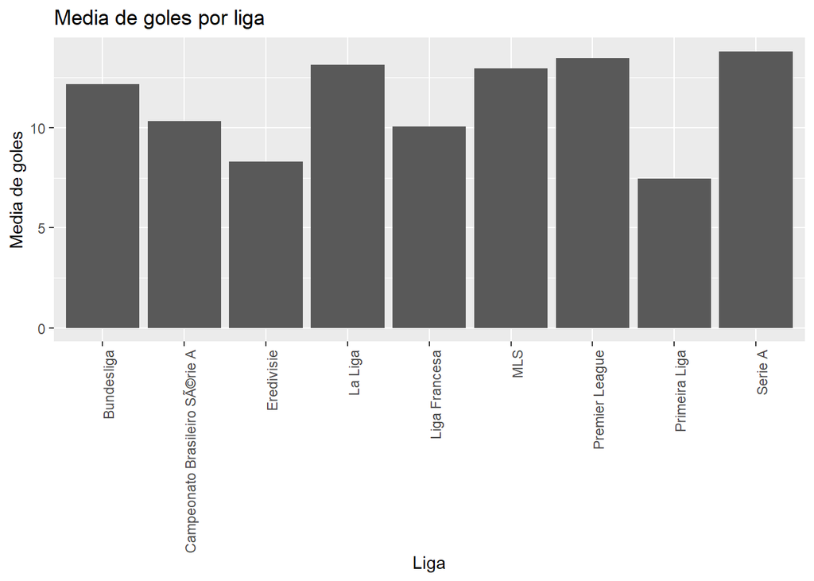

```r
# Carga las bibliotecas necesarias
library(ggplot2)
library(dplyr)

# Calcula la media de goles por liga
goles_por_liga <- datos %>%
  group_by(League) %>%
  summarise(mean_goals = mean(Goals, na.rm = TRUE))

# Crea el diagrama de barras
ggplot(goles_por_liga, aes(x = League, y = mean_goals)) +
  geom_bar(stat = 'identity') +
  theme(axis.text.x = element_text(angle = 90, hjust = 1)) +
  labs(title = "Media de goles por liga", x = "Liga", y = "Media de goles")
```

[figure not shown]

```r
# Crea el diagrama de barras agrupado
ggplot(datos, aes(x = League, y = Goals, fill = Player.Names)) +
  geom_bar(stat = 'identity', position = 'dodge') +
  theme(axis.text.x = element_text(angle = 90, hjust = 1)) +
  labs(title = "Media de goles por jugador en cada liga", x = "Liga", y = "Media de goles", fill = "Jugador")
```

## EXPLICACION DIAGRAMA

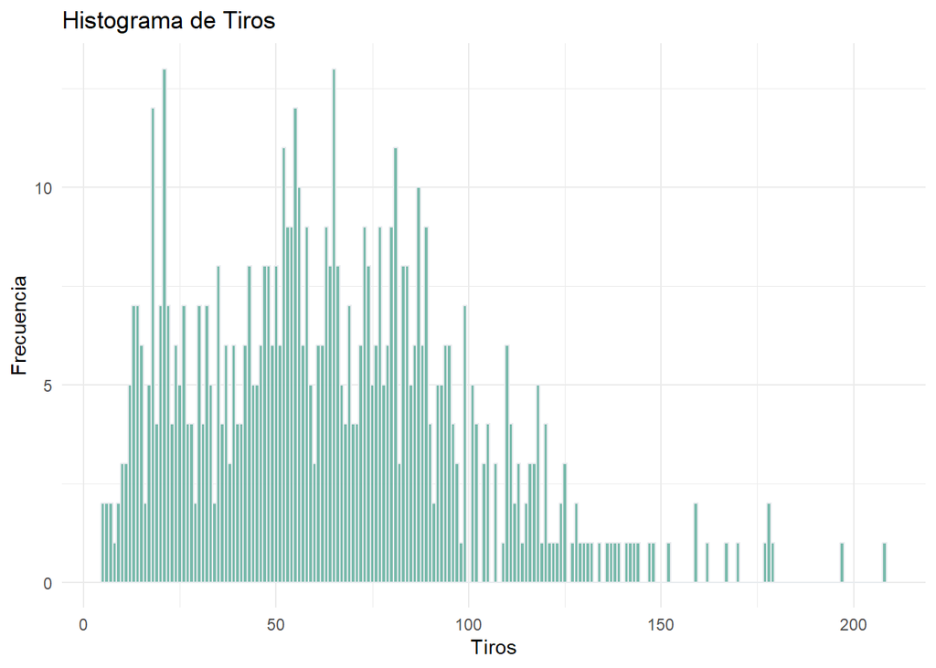

```r
# Carga la librería ggplot2
library(ggplot2)

# Genera el histograma de la variable 'Shots'
ggplot(datos, aes(x=Shots)) +
  geom_histogram(binwidth=1, fill="#69b3a2", color="#e9ecef", alpha=0.9) +
  labs(title="Histograma de Tiros", x="Tiros", y="Frecuencia") +
  theme_minimal()
```

## Interpretación del histograma:

El eje x representa el número de tiros y el eje y representa la frecuencia de cada conteo de tiros.En otras palabras, te indica cuántas veces un jugador ha realizado cierto número de tiros en el conjunto de datos.

## HISTOGRAMA DE GOLES

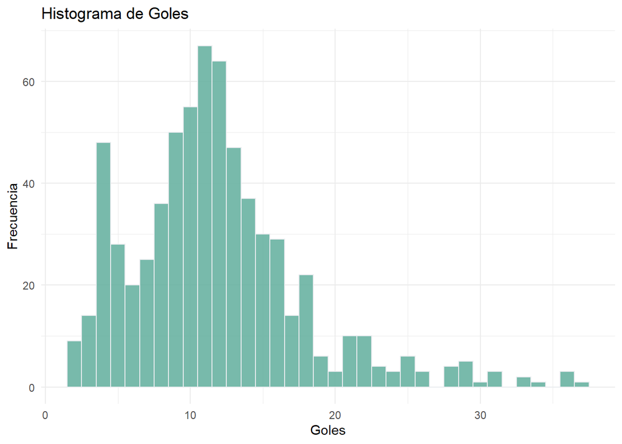

```r
# Carga la librería ggplot2
library(ggplot2)

# Genera el histograma de la variable 'Goals'
ggplot(datos, aes(x=Goals)) +
  geom_histogram(binwidth=1, fill="#69b3a2", color="#e9ecef", alpha=0.9) +
  labs(title="Histograma de Goles", x="Goles", y="Frecuencia") +
  theme_minimal()
```

## Interpretación del histograma:

Este histograma mostrará la distribución de la variable “Goals” (Goles). El eje x representa la cantidad de goles y el eje y representa la frecuencia, es decir, cuántas veces ocurre una cierta cantidad de goles en el conjunto de datos.

## DIAGRAMA CAJA SIMPLES

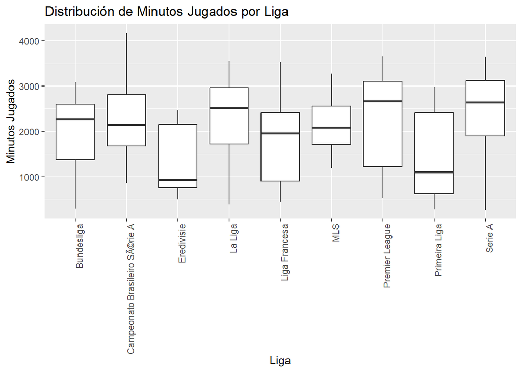

```r
# Carga la librería ggplot2
library(ggplot2)

# Genera el boxplot
ggplot(datos, aes(x = League, y = Mins)) +
  geom_boxplot() +
  labs(title = "Distribución de Minutos Jugados por Liga", x = "Liga", y = "Minutos Jugados") +
  theme(axis.text.x = element_text(angle = 90, hjust = 1))
```

## Interpretación del diagrama de caja:

El diagrama de cajas te permite visualizar la distribución de los minutos jugados por liga.Cada caja muestra los cuartiles de los minutos jugados en una liga específica, con la línea en el medio de la caja que indica la mediana, es decir, el valor medio de los minutos jugados. Los bigotes se extienden desde la caja para abarcar el resto de la distribución,con excepción de los puntos que se consideran valores atípicos

## DIAGRAMA CAJA AGRUPADO

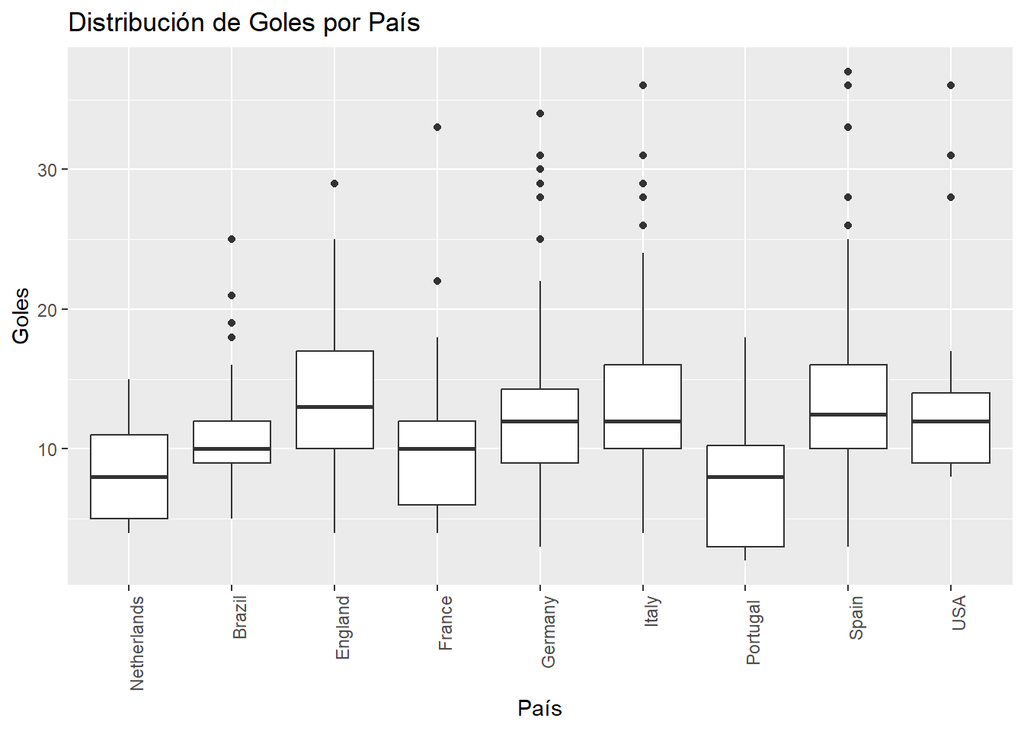

```r
# Carga la librería ggplot2
library(ggplot2)

# Genera el boxplot
ggplot(datos, aes(x = Country, y = Goals)) +
  geom_boxplot() +
  labs(title = "Distribución de Goles por País", x = "País", y = "Goles") +
  theme(axis.text.x = element_text(angle = 90, hjust = 1))
```

## Interpretación del diagrama de caja:

El diagrama de cajas te permite visualizar la distribución de los goles por país. Cada caja muestra los cuartiles de los goles en un país específico, con la línea en el medio de la caja que indica la mediana, es decir, el valor medio de los goles. Los bigotes se extienden desde la caja para abarcar el resto de la distribución, con excepción de los puntos que se consideran valores atípicos.

## DIAGRAMA AGRUPADO GOLES

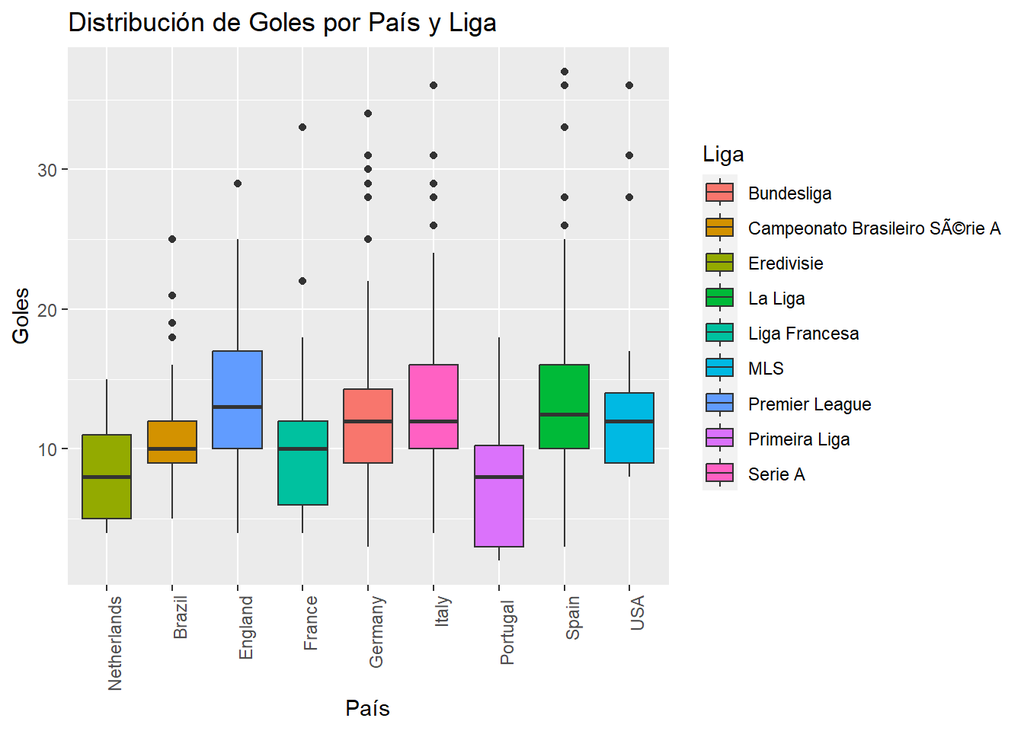

```r
# Carga la librería ggplot2
library(ggplot2)

# Genera el boxplot
ggplot(datos, aes(x = Country, y = Goals, fill = League)) +
  geom_boxplot() +
  labs(title = "Distribución de Goles por País y Liga", x = "País", y = "Goles") +
  theme(axis.text.x = element_text(angle = 90, hjust = 1)) +
  guides(fill=guide_legend(title="Liga"))
```

## Relación entre los “Goals” (Goles) y el “xG” (Expected Goals o Goles Esperados)

```r
# Cargar la libreria
library(ggplot2)


# Crear el modelo de regresion lineal
modelo <- lm(Goals ~ xG, data = datos)

# Mostrar el resumen del modelo
summary(modelo)
```

```
##
## Call:
## lm(formula = Goals ~ xG, data = datos)
##
## Residuals:
##    Min     1Q Median     3Q    Max
## -7.949 -1.554 -0.129  1.263  9.764
##
## Coefficients:
##             Estimate Std. Error t value Pr(>|t|)
## (Intercept)  2.23001    0.19978   11.16   <2e-16 ***
## xG           0.94700    0.01722   54.98   <2e-16 ***
## ---
## Signif. codes:  0 '***' 0.001 '**' 0.01 '*' 0.05 '.' 0.1 ' ' 1
##
## Residual standard error: 2.531 on 658 degrees of freedom
## Multiple R-squared:  0.8212, Adjusted R-squared:  0.821
## F-statistic:  3023 on 1 and 658 DF,  p-value: < 2.2e-16
```

## Interpretación del modelo de regresión lineal:

Los coeficientes del modelo te dicen cómo cambia la variable dependiente con cada unidad de cambio en la variable independiente. El valor p te indica si el coeficiente es estadísticamente significativo. Si el valor p es menor que 0.05, puedes concluir que hay una relación significativa entre las variables.

El estadístico F te indica si tu modelo es significativamente mejor que un modelo sin predictores. En otras palabras, si hay una relación significativa entre todas las variables independientes y la variable dependiente.

El R-cuadrado te indica cuánta de la variabilidad en la variable dependiente es explicada por tu modelo. Un R-cuadrado de 1 significa que tu modelo explica toda la variabilidad, mientras que un R-cuadrado de 0 significa que tu modelo no explica ninguna de la variabilidad

## Modelo de regresión lineal para cada Club

```r
# Aplicar la regresión lineal a cada Club
modelos_club <- by(datos, datos$Club, function(df) lm(Shots ~ Goals, data = df))

# Mostrar el resumen de los modelos
lapply(modelos_club, summary)
```

```
## $`(ACM)`
##
## Call:
## lm(formula = Shots ~ Goals, data = df)
##
## Residuals:
##      77     225     303     399     559
##  26.911   7.046  -8.737 -11.954 -13.265
##
## Coefficients:
##             Estimate Std. Error t value Pr(>|t|)
## (Intercept)   -8.626     19.942  -0.433   0.6946
## Goals          5.689      1.118   5.091   0.0147 *
## ---
## Signif. codes:  0 '***' 0.001 '**' 0.01 '*' 0.05 '.' 0.1 ' ' 1
##
## Residual standard error: 19.74 on 3 degrees of freedom
## Multiple R-squared:  0.8962, Adjusted R-squared:  0.8617
## F-statistic: 25.91 on 1 and 3 DF,  p-value: 0.01465
##
##
## $`(AJA)`
##
## Call:
## lm(formula = Shots ~ Goals, data = df)
##
## Residuals:
##    Min     1Q Median     3Q    Max
## -10.49  -7.52  -2.02   8.06  13.10
##
## Coefficients:
##             Estimate Std. Error t value Pr(>|t|)
## (Intercept)   -8.964      9.568  -0.937  0.38498
## Goals          5.351      1.209   4.426  0.00444 **
## ---
## Signif. codes:  0 '***' 0.001 '**' 0.01 '*' 0.05 '.' 0.1 ' ' 1
##
## Residual standard error: 9.813 on 6 degrees of freedom
## Multiple R-squared:  0.7655, Adjusted R-squared:  0.7264
## F-statistic: 19.59 on 1 and 6 DF,  p-value: 0.004443
```

[output cut: 3259 more lines]

```
##
## $Tim
##
## Call:
## lm(formula = Shots ~ Goals, data = df)
##
## Residuals:
## ALL 1 residuals are 0: no residual degrees of freedom!
##
## Coefficients: (1 not defined because of singularities)
##             Estimate Std. Error t value Pr(>|t|)
## (Intercept)       55        NaN     NaN      NaN
## Goals             NA         NA      NA       NA
##
## Residual standard error: NaN on 0 degrees of freedom
```

## Interpretación de los modelos de regresión lineal:

los coeficientes del modelo te dirán cómo cambia la variable dependiente (“Shots”) con cada unidad de cambio en la variable independiente (“Goals”) para cada Club. El valor p te indica si este cambio es estadísticamente significativo para cada Club.

## Relación entre “Matches_Played” (Partidos Jugados) y “Goals” (Goles), agrupados por la “League” (Liga)

```r
# Aplicar la regresión lineal a cada Liga
modelos_liga <- by(datos, datos$League, function(df) lm(Matches_Played ~ Goals, data = df))

# Mostrar el resumen de los modelos
lapply(modelos_liga, summary)
```

```
## $Bundesliga
##
## Call:
## lm(formula = Matches_Played ~ Goals, data = df)
##
## Residuals:
##      Min       1Q   Median       3Q      Max
## -15.9391  -5.6851   0.1403   5.8328  13.7435
##
## Coefficients:
##             Estimate Std. Error t value Pr(>|t|)
## (Intercept)   9.6533     1.5922   6.063 2.50e-08 ***
## Goals         0.9603     0.1174   8.179 1.05e-12 ***
## ---
## Signif. codes:  0 '***' 0.001 '**' 0.01 '*' 0.05 '.' 0.1 ' ' 1
##
## Residual standard error: 7 on 98 degrees of freedom
## Multiple R-squared:  0.4057, Adjusted R-squared:  0.3996
## F-statistic:  66.9 on 1 and 98 DF,  p-value: 1.051e-12
##
##
## $`Campeonato Brasileiro SÃ©rie A`
##
## Call:
## lm(formula = Matches_Played ~ Goals, data = df)
##
## Residuals:
##      Min       1Q   Median       3Q      Max
## -12.6883  -4.5831  -0.5831   5.3327  12.4591
##
## Coefficients:
##             Estimate Std. Error t value Pr(>|t|)
## (Intercept)  13.3725     2.1340   6.266 9.91e-09 ***
## Goals         1.0211     0.1969   5.184 1.17e-06 ***
## ---
## Signif. codes:  0 '***' 0.001 '**' 0.01 '*' 0.05 '.' 0.1 ' ' 1
##
## Residual standard error: 6.443 on 98 degrees of freedom
## Multiple R-squared:  0.2152, Adjusted R-squared:  0.2072
## F-statistic: 26.88 on 1 and 98 DF,  p-value: 1.165e-06
```

[output cut: 132 more lines]

```
##
## Residuals:
##      Min       1Q   Median       3Q      Max
## -19.4097  -6.3383   0.6189   5.5975  16.7045
##
## Coefficients:
##             Estimate Std. Error t value Pr(>|t|)
## (Intercept)  11.1527     1.7225   6.475 3.79e-09 ***
## Goals         1.0143     0.1118   9.074 1.24e-14 ***
## ---
## Signif. codes:  0 '***' 0.001 '**' 0.01 '*' 0.05 '.' 0.1 ' ' 1
##
## Residual standard error: 7.618 on 98 degrees of freedom
## Multiple R-squared:  0.4566, Adjusted R-squared:  0.451
## F-statistic: 82.33 on 1 and 98 DF,  p-value: 1.24e-14
```

## Interpretación de los modelos de regresión lineal:

Similar a los modelos anteriores, los coeficientes del modelo indican cómo cambia la variable dependiente (“Matches_Played”) con cada unidad de cambio en la variable independiente (“Goals”) para cada Liga. El valor p indica si este cambio es estadísticamente significativo para cada Liga.

El estadístico F y los valores R-cuadrados permiten entender qué tan bien el modelo se ajusta a los datos para cada Liga. Específicamente, el estadístico F indica si hay una relación significativa entre “Matches_Played” y “Goals” para cada Liga, y el valor R-cuadrado indica cuánta de la variabilidad en “Matches_Played” es explicada por “Goals” para cada Liga

## APLICACION REGRESION NO LINEAL

Vamos a tomar un ejemplo de un modelo polinómico cuadrático, que es un tipo de modelo no lineal.

Supongamos que queremos modelar la relación entre los “Goals” y “Matches_Played” de manera no lineal, por ejemplo, podríamos usar un modelo cuadrático:

```r
# Aplicar la regresión no lineal a los datos
model_nl <- lm(Matches_Played ~ poly(Goals, 2), data = datos)

# Mostrar el resumen del modelo
summary(model_nl)
```

```
##
## Call:
## lm(formula = Matches_Played ~ poly(Goals, 2), data = datos)
##
## Residuals:
##     Min      1Q  Median      3Q     Max
## -21.849  -3.713   0.000   3.540  16.314
##
## Coefficients:
##                  Estimate Std. Error t value Pr(>|t|)
## (Intercept)       22.3712     0.2348   95.27   <2e-16 ***
## poly(Goals, 2)1  169.3285     6.0328   28.07   <2e-16 ***
## poly(Goals, 2)2 -100.6101     6.0328  -16.68   <2e-16 ***
## ---
## Signif. codes:  0 '***' 0.001 '**' 0.01 '*' 0.05 '.' 0.1 ' ' 1
##
## Residual standard error: 6.033 on 657 degrees of freedom
## Multiple R-squared:  0.6187, Adjusted R-squared:  0.6175
## F-statistic:   533 on 2 and 657 DF,  p-value: < 2.2e-16
```

## PARA CADA LIGA

```r
# Aplicar la regresión no lineal a cada Liga
modelos_nl_liga <- by(datos, datos$League, function(df) lm(Matches_Played ~ poly(Goals, 2), data = df))

# Mostrar el resumen de los modelos
lapply(modelos_nl_liga, summary)
```

```
## $Bundesliga
##
## Call:
## lm(formula = Matches_Played ~ poly(Goals, 2), data = df)
##
## Residuals:
##      Min       1Q   Median       3Q      Max
## -18.6172  -3.6961   0.8749   4.1933  12.9433
##
## Coefficients:
##                 Estimate Std. Error t value Pr(>|t|)
## (Intercept)       21.350      0.606  35.233  < 2e-16 ***
## poly(Goals, 2)1   57.256      6.060   9.449 2.08e-15 ***
## poly(Goals, 2)2  -35.222      6.060  -5.813 7.85e-08 ***
## ---
## Signif. codes:  0 '***' 0.001 '**' 0.01 '*' 0.05 '.' 0.1 ' ' 1
##
## Residual standard error: 6.06 on 97 degrees of freedom
## Multiple R-squared:  0.5592, Adjusted R-squared:  0.5501
## F-statistic: 61.53 on 2 and 97 DF,  p-value: < 2.2e-16
##
##
## $`Campeonato Brasileiro SÃ©rie A`
##
## Call:
## lm(formula = Matches_Played ~ poly(Goals, 2), data = df)
##
## Residuals:
##     Min      1Q  Median      3Q     Max
## -13.902  -3.846  -0.225   4.381  12.961
##
## Coefficients:
##                 Estimate Std. Error t value Pr(>|t|)
## (Intercept)      23.9200     0.6268  38.162  < 2e-16 ***
## poly(Goals, 2)1  33.4013     6.2681   5.329 6.42e-07 ***
## poly(Goals, 2)2 -16.0227     6.2681  -2.556   0.0121 *
## ---
## Signif. codes:  0 '***' 0.001 '**' 0.01 '*' 0.05 '.' 0.1 ' ' 1
##
## Residual standard error: 6.268 on 97 degrees of freedom
```

[output cut: 141 more lines]

```
## Residuals:
##      Min       1Q   Median       3Q      Max
## -23.0663  -3.0456   0.0754   2.9588  15.9184
##
## Coefficients:
##                 Estimate Std. Error t value Pr(>|t|)
## (Intercept)      25.1700     0.6125  41.097  < 2e-16 ***
## poly(Goals, 2)1  69.1253     6.1246  11.287  < 2e-16 ***
## poly(Goals, 2)2 -45.2693     6.1246  -7.391 5.15e-11 ***
## ---
## Signif. codes:  0 '***' 0.001 '**' 0.01 '*' 0.05 '.' 0.1 ' ' 1
##
## Residual standard error: 6.125 on 97 degrees of freedom
## Multiple R-squared:  0.6524, Adjusted R-squared:  0.6452
## F-statistic: 91.01 on 2 and 97 DF,  p-value: < 2.2e-16
```

## Interpretación del modelo de regresión no lineal:

Los coeficientes del modelo representan los términos del polinomio. Por ejemplo, para un modelo cuadrático, los coeficientes representan el término constante, el término lineal y el término cuadrático. El valor p asociado a cada coeficiente indica si ese término es estadísticamente significativo en el modelo.

El valor R-cuadrado en cada modelo representa la cantidad de variabilidad en “Matches_Played” que se puede explicar por el modelo no lineal para cada Liga. El estadístico F te permite entender si el modelo proporciona un mejor ajuste a los datos que un modelo que solo incluye el término constante

```r
model <- lm(Goals ~ Prolific_Player, data = datos)
summary(model)
```

```
##
## Call:
## lm(formula = Goals ~ Prolific_Player, data = datos)
##
## Residuals:
##      Min       1Q   Median       3Q      Max
## -12.3176  -3.4028  -0.3176   2.5972  22.6824
##
## Coefficients:
##                     Estimate Std. Error t value Pr(>|t|)
## (Intercept)          10.4028     0.2752  37.804   <2e-16 ***
## Prolific_PlayerTRUE   3.9148     0.4631   8.453   <2e-16 ***
## ---
## Signif. codes:  0 '***' 0.001 '**' 0.01 '*' 0.05 '.' 0.1 ' ' 1
##
## Residual standard error: 5.686 on 658 degrees of freedom
## Multiple R-squared:  0.09795,    Adjusted R-squared:  0.09658
## F-statistic: 71.45 on 1 and 658 DF,  p-value: < 2.2e-16
```

```r
# Crear un nuevo data frame con los datos de 'Prolific_Player' para los que queremos predecir 'Goals'
new_data <- data.frame(Prolific_Player = c("TRUE", "FALSE"))
new_data$Prolific_Player <- as.logical(new_data$Prolific_Player)


# Hacer las predicciones
predictions <- predict(model, newdata = new_data)


# Imprimir las predicciones
print(predictions)
```

```
##        1        2
## 14.31760 10.40281
```

## INTERPRETACCION DEL MODELO DE REGRESION

Este modelo de regresión lineal predice la cantidad de goles (“Goals”) que un jugador puede marcar basado en si es un jugador prolífico (“Prolific_Player”) o no. La variable “Prolific_Player” es una variable categórica que ha sido convertida en una variable lógica (verdadero/falso) para este análisis.

```r
# Construyendo el modelo de regresión
model2 <- lm(Goals ~ OnTarget, data = datos)
summary(model2)
```

```
##
## Call:
## lm(formula = Goals ~ OnTarget, data = datos)
##
## Residuals:
##      Min       1Q   Median       3Q      Max
## -12.9318  -1.6302  -0.1959   1.6459  10.7525
##
## Coefficients:
##             Estimate Std. Error t value Pr(>|t|)
## (Intercept) 2.828057   0.235203   12.02   <2e-16 ***
## OnTarget    0.315767   0.007184   43.95   <2e-16 ***
## ---
## Signif. codes:  0 '***' 0.001 '**' 0.01 '*' 0.05 '.' 0.1 ' ' 1
##
## Residual standard error: 3.018 on 658 degrees of freedom
## Multiple R-squared:  0.746,  Adjusted R-squared:  0.7456
## F-statistic:  1932 on 1 and 658 DF,  p-value: < 2.2e-16
```

```r
# Creando un nuevo data frame con los datos 'OnTarget' para los que queremos predecir 'Goals'
new_data2 <- data.frame(OnTarget = c(10, 20, 30))

# Haciendo las predicciones
predictions2 <- predict(model2, newdata = new_data2)

# Imprimiendo las predicciones
print(predictions2)
```

```
##         1         2         3
##  5.985731  9.143406 12.301080
```

## INTERPRETACION DEL MODELO DE REGRESION

Las predicciones generadas por este modelo (predictions2) son las estimaciones del número de goles que un jugador marcaría dada una cierta cantidad de tiros a portería. Específicamente, este modelo predice cuántos goles se marcarían si un jugador tiene 10, 20 o 30 tiros a portería

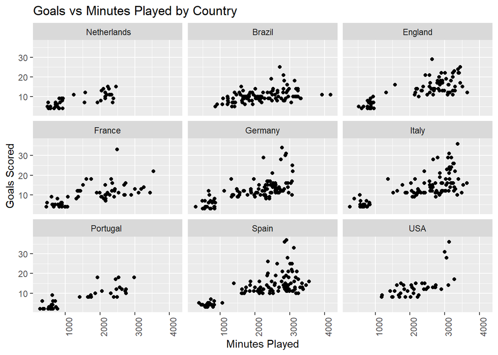

```r
library(ggplot2)

ggplot(datos, aes(x=Mins, y=Goals)) +
  geom_point() +
  facet_wrap(~Country) +
  theme(axis.text.x = element_text(angle = 90, hjust = 1)) +
  labs(x="Minutes Played", y="Goals Scored", title="Goals vs Minutes Played by Country")
```

## INTERPRETACION DE LA GRAFICA

La gráfica es un diagrama de dispersión que representa los “Goals” (goles) en función de los “Mins” (minutos jugados), y cada punto en la gráfica representa un jugador individual. Además, la gráfica se divide en múltiples paneles a través de la faceta “Country” (país), lo que significa que hay un diagrama de dispersión por país.

Eje X - “Minutes Played” (Minutos Jugados): Representa el número total de minutos que un jugador ha jugado.

Eje Y - “Goals Scored” (Goles Anotados): Representa el número total de goles que un jugador ha anotado.

Facetas - “Country” (País): Cada panel representa un país diferente.

## DIAGRAMA DE BARRAS CON FACETAS

[figure not shown]

```r
ggplot(datos, aes(x = Club)) +
  geom_bar() +
  facet_wrap(~Country) +
  theme(axis.text.x = element_text(angle = 45, hjust = 1)) +
  labs(x = "Club", y = "Count", title = "Numero de jugadores de cada Pais")
```

## HISTOGRAMA CON FACETAS

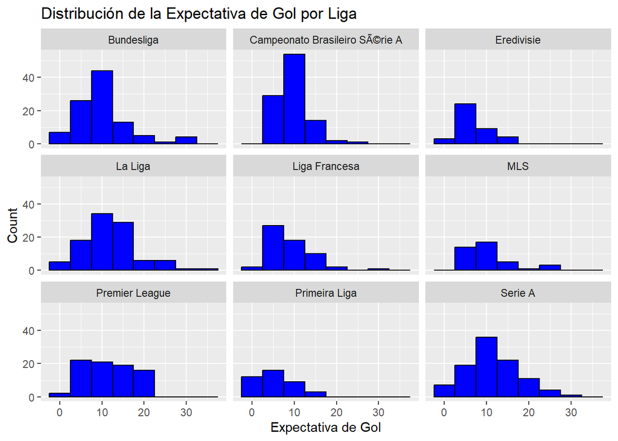

```r
ggplot(datos, aes(x = xG)) +
  geom_histogram(binwidth = 5, fill = "blue", color = "black") +
  facet_wrap(~League) +
  labs(x = "Expectativa de Gol", y = "Count", title = "Distribución de la Expectativa de Gol por Liga")
```

## INTERPRETACION DEL HISTOGRAMA

El eje x representa la expectativa de gol (xG), y el eje y representa la cantidad de jugadores (Count) que caen en cada intervalo de expectativa de goL

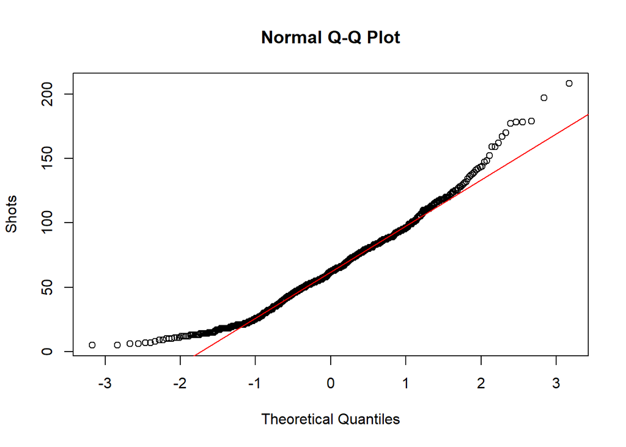

```r
# Carga las librerías necesarias
library(ggplot2)

# Crear el gráfico Q-Q para 'Shots'
qqnorm(datos$Shots, ylab = "Shots")
qqline(datos$Shots, col = "red") # Añade la línea de referencia
```

```r
# Cálculo de los percentiles observados
observed_percentiles <- quantile(datos$Shots, probs = c(0.25, 0.5, 0.75))

# Cálculo de los percentiles teóricos
theoretical_percentiles <- qnorm(p = c(0.25, 0.5, 0.75), mean = mean(datos$Shots), sd = sd(datos$Shots))

# Crear un dataframe para comparar los percentiles
comparison <- data.frame(Observed = observed_percentiles, Theoretical = theoretical_percentiles)
print(comparison)
```

```
##     Observed Theoretical
## 25%    37.75    40.60951
## 50%    62.00    64.17727
## 75%    86.00    87.74504
```

## PIVOTAR DE FORMATO ANCHO A LARGO

```r
library(tidyverse)
datos_largos <- datos %>%
  pivot_longer(
    cols = c(Matches_Played:Mostly_Played),
    names_to = "Variable",
    values_to = "Valor"
  )
head(datos_largos)
```

```
## # A tibble: 6 × 6
##   Player.Names    Country League  Club  Variable           Valor
##   <chr>           <chr>   <chr>   <chr> <chr>              <dbl>
## 1 Juanmi Callejon Spain   La Liga (BET) Matches_Played     19
## 2 Juanmi Callejon Spain   La Liga (BET) Substitution       16
## 3 Juanmi Callejon Spain   La Liga (BET) Mins             1849
## 4 Juanmi Callejon Spain   La Liga (BET) Goals              11
## 5 Juanmi Callejon Spain   La Liga (BET) xG                  6.62
## 6 Juanmi Callejon Spain   La Liga (BET) xG.Per.Avg.Match    0.34
```